# Google Symptoms anosmia + ageusia indicator vs GHT indicator

Nat

Anosmia and ageusia are strongly correlated, but quite unusual (~0.5 scaled search popularity compared to the most popular health related search, defined as 100). Searches on these topics were high in late March (the beginning of the nation-wide awareness of COVID) and in late June to July, before dying down again in August. Search popularity in September is only slightly more than baseline (January and February 2020).

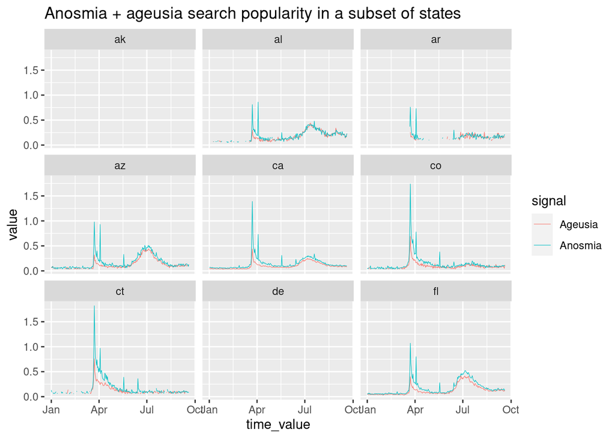

Google Health Trends (GHT) and Google Symptoms are only directly comparable at the state level, since GS can’t be aggregated or divided due to the GS scaling process works (GS values are a scaled unitless version of per-capita number of searches on a given health topic).

After scaling the GS A+A indicator, we can see that the general shape of GS A+A and GHT is similar. Many states exhibit an initial increase in late March in both indicators.However, the July “bump” seen in GS A+A is barely visible in GHT. GS A+A is smoother than both the raw and smoothed GHT indicator, which is smoother for large-population areas. GS A+A is approximately equally smooth for small and large-population states (in the subset shown, consider California and Florida vs others).

[figure not shown]

As expected, there is clearly a positive relationship between GS A+A and GHT.

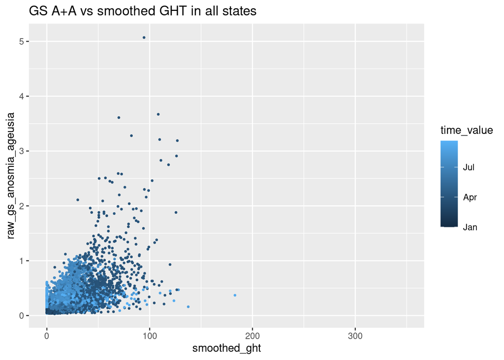

Unexpectedly, zeroes in GS A+A, many representing missing and/or low-count data, correspond to very high GHT values. This is concerning given that we expect missing GS observations to occur when sample size is small and search term is rare, causing data to be redacted for privacy reasons.

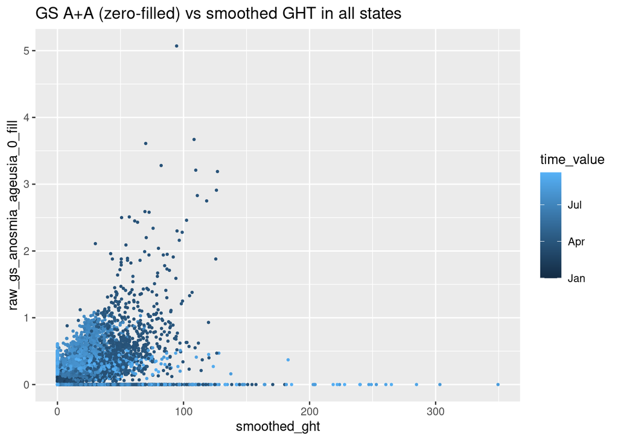

Missing values sometimes correspond to large values in raw GHT as well, so the smoothing process is not the culprit.

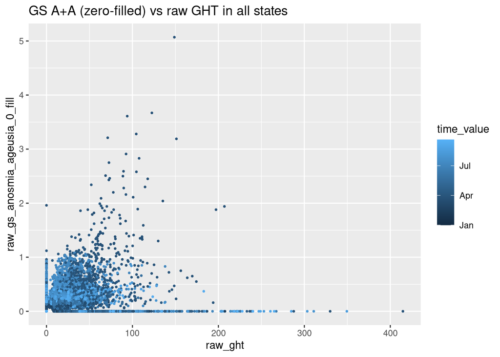

Let’s look into these low GS-high GHT points to see if we can figure out what’s causing them. Data show below is raw GHT where GS is missing.

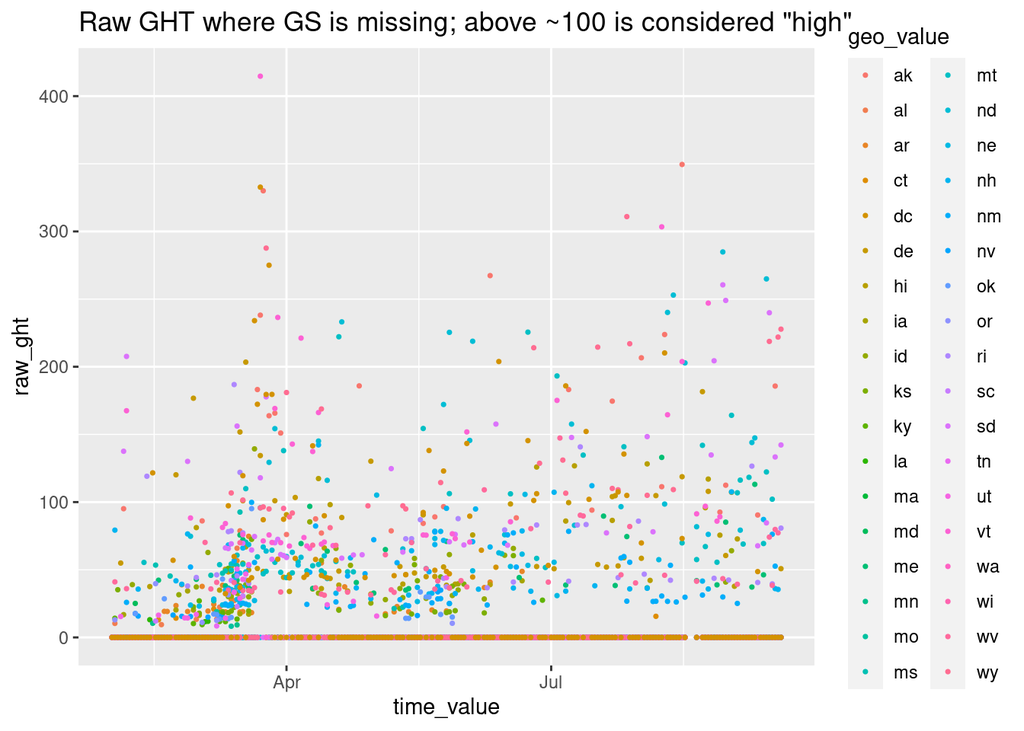

Clearly, missing GS values occur in the majority of states (36 of 51), with a large proportion corresponding to zeroes in GHT. Based on the previous plot, we consider any GHT value above approximately 100 to be “high” given the distribution of all GHT values.

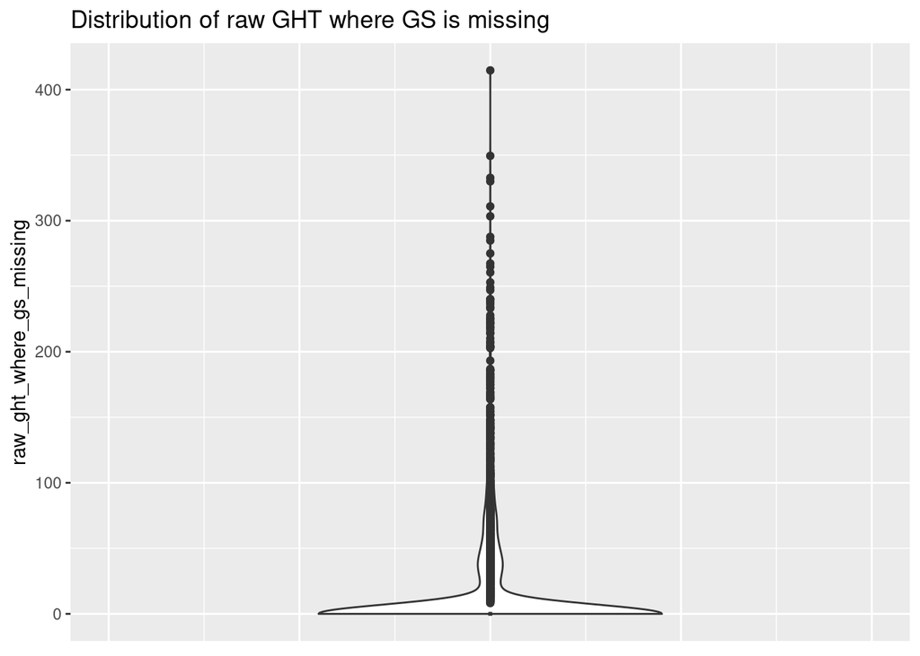

```
##    Min. 1st Qu.  Median    Mean 3rd Qu.    Max.
##    0.00    0.00    0.00   16.25    0.00  414.71
```

Looking at the distribution and summary statistics, we can see that at least 75% of values equal 0. According to the IQR definition, any values not equal to 0 are outliers.

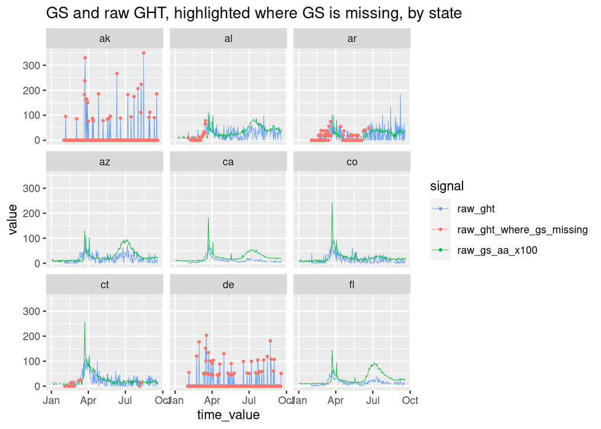

GHT corresponding to missing GS is much higher than baseline/background GHT only in low-population states (AK, DE). These states are characterized by partially or completely-missing GS data and high variability in GHT, i.e. most values at or near 0, with the occasional huge increase into the hundreds.

It seems likely that jumps in search popularity are due to each Google user in that region representing a large portion of activity. Take an extreme example: a region with only 2 people will, at any one time, be unlikely to search for rare search term *x*. When someone does search *x*, however, the search incidence will very briefly jump from 0 to 50%. A region with many more people will see a much lower but more consistent search incidence for the term.

I’m not sure exactly how GHT scaling/signal creation works and documentation is lacking/unavailable. Does this sample-size hypothesis make sense given how GHT is constructed?

In moderate-population states (AL, CT), GHT values corresponding to missing GS are in line with GHT and GS trends and historical values. Large-population states (FL, CA) don’t have any missing GS values.

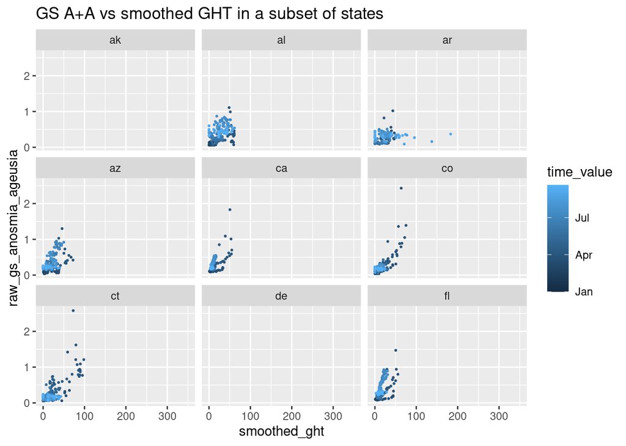

The trajectory and correlation of GS A+A vs GHT varies by state.

```
## # A tibble: 51 x 2
##    geo_value  corr
##    <chr>     <dbl>
##  1 ga        0.761
##  2 ny        0.755
##  3 il        0.728
##  4 nj        0.728
##  5 la        0.697
##  6 tx        0.696
##  7 fl        0.688
##  8 mo        0.656
##  9 in        0.628
## 10 tn        0.611
## # … with 41 more rows
```

Correlation between GS A+A and GHT varies widely by state (over all time).

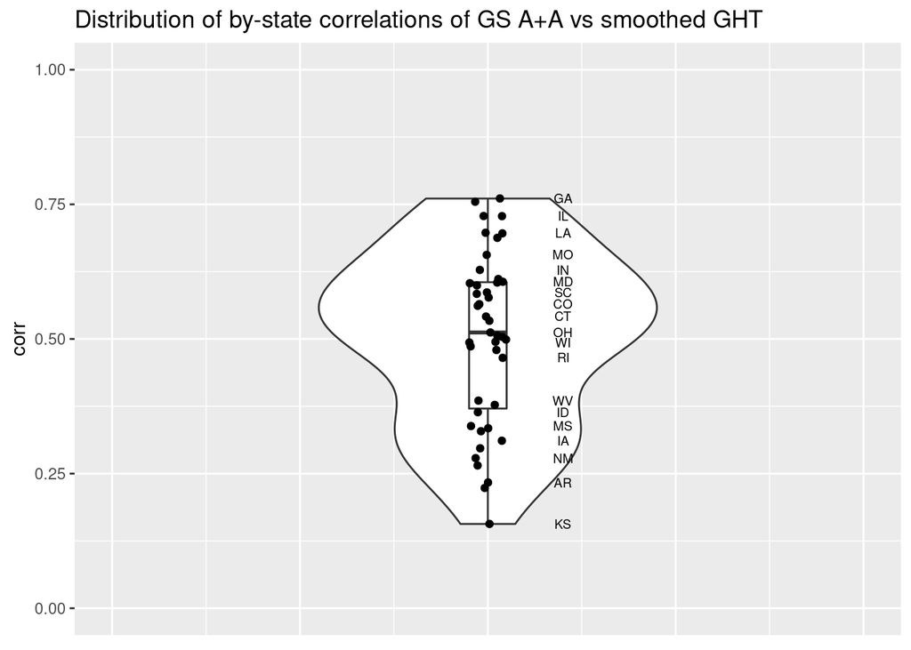

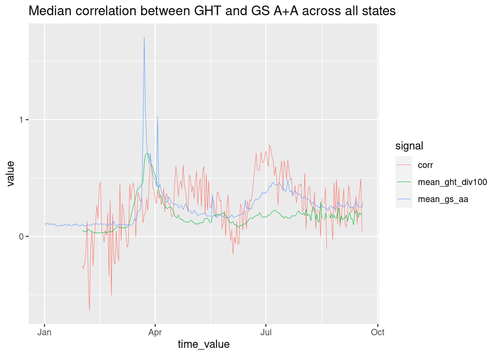

## Rudimentary prediction problem

Here we use code liberally borrowed from a [blog post](https://github.com/cmu-delphi/delphi-blog/blob/google-survey/content/post/google-fb-forecast-demo/demo.R) to perform a prediction task.

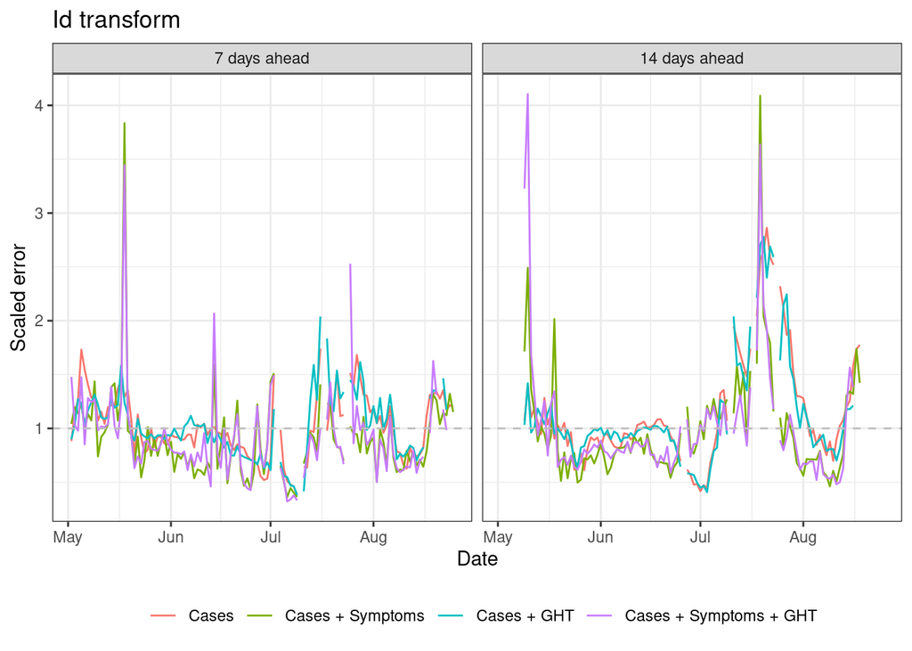

It’s not clear from this comparison if adding in GS anosmia and ageusia signals was helpful. We can see that during some time periods, median scaled error for the cases + symptoms model is lower than that for the cases-only model, but it is more variable. There’s also a particularly bad error in mid-May.

It appears that cases and cases + GHT models are very similar, and cases + symptoms and cases + symptoms + GHT models are very similar, especially for the 14 days ahead models. This implies that cases and GS contribute the most to predictive power, with GHT apparently not helping much.

Test period: 2020-05-02 to 2020-08-25 , common time period

| Model | Target | Median scaled error | Test days |
| --- | --- | --- | --- |
| Cases | 7 days ahead | 0.910 | 113 |
| Cases + Symptoms | 7 days ahead | 0.834 | 113 |
| Cases + GHT | 7 days ahead | 0.900 | 113 |
| Cases + Symptoms + GHT | 7 days ahead | 0.839 | 113 |
| Cases | 14 days ahead | 0.991 | 101 |
| Cases + Symptoms | 14 days ahead | 0.892 | 101 |
| Cases + GHT | 14 days ahead | 0.963 | 101 |
| Cases + Symptoms + GHT | 14 days ahead | 0.901 | 101 |

Calculating median scaled error over all dates and all states for a given model, we see again that cases and cases + GHT, and cases + symptoms and cases + symptoms + GHT models are very similar.

“Are these differences in median scaled errors significant? It’s hard to say [for certain, given the spatial and temporal dependence of the data], but some basic hypothesis testing suggests that they probably are: below we conduct a sign test for whether the difference in the “Cases” model’s scaled error and each other model’s scaled error is centered at zero" ([source](https://delphi.cmu.edu/blog/2020/09/21/can-symptoms-surveys-improve-covid-19-forecasts/)).

| Comparison | Target | P-value |
| --- | --- | --- |
| Cases vs Cases + Symptoms | 7 days ahead | 0.00e+00 |
| Cases vs Cases + Symptoms | 14 days ahead | 0.00e+00 |
| Cases vs Cases + GHT | 7 days ahead | 1.29e-05 |
| Cases vs Cases + GHT | 14 days ahead | 0.00e+00 |
| Cases vs Cases + Symptoms + GHT | 7 days ahead | 6.00e-07 |
| Cases vs Cases + Symptoms + GHT | 14 days ahead | 0.00e+00 |

Differences in model fit are (very) significantly different, ignoring dependence structure at the moment.

“To mitigate the dependence across time (which intuitively seems to matter more than that across space), we recomputed these tests in a stratified way, where for each day we run a sign test on the scaled errors between two models over all [geographic regions]. The results are plotted as histograms below”, where one count corresponds to one prediction date ([source](https://delphi.cmu.edu/blog/2020/09/21/can-symptoms-surveys-improve-covid-19-forecasts/)).

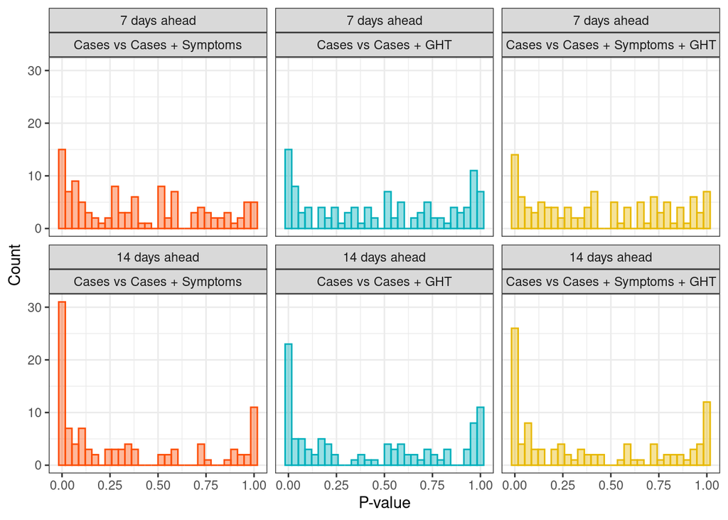

If the differences between models were *not* significant, we’d expect the distribution of p-values to be uniform. That is distinctly not what we see here. Model differences at both 7 and 14 days ahead have elevated (compared to expected) numbers of low p-values, suggesting significance. However, 14-day ahead comparisons look *more* significant across all alternative models. So it appears that additional predictors, especially GS, are useful for farther-future predictions, rather than near-future where number of cases is largely sufficient.

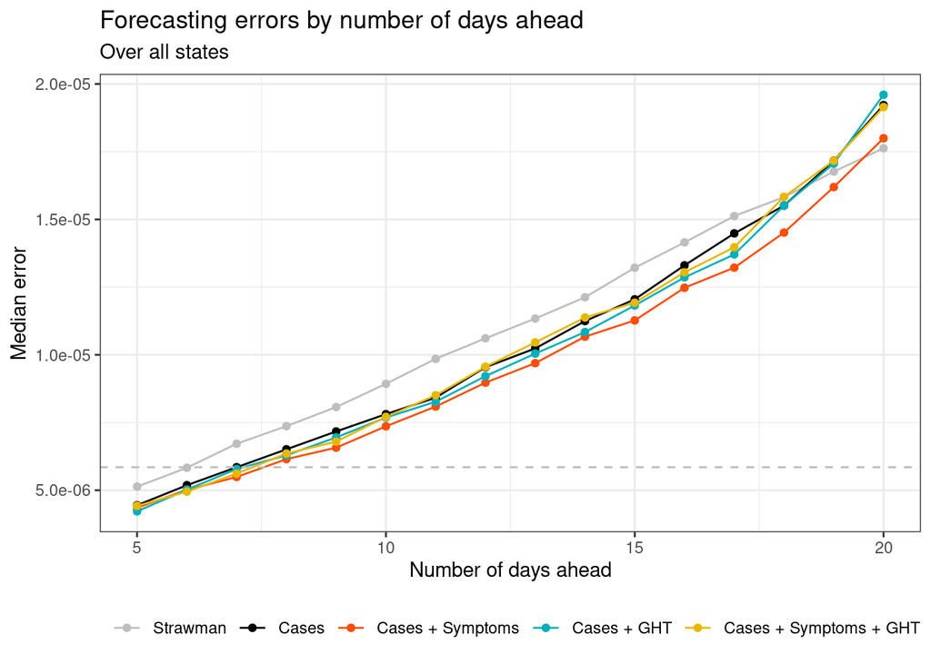

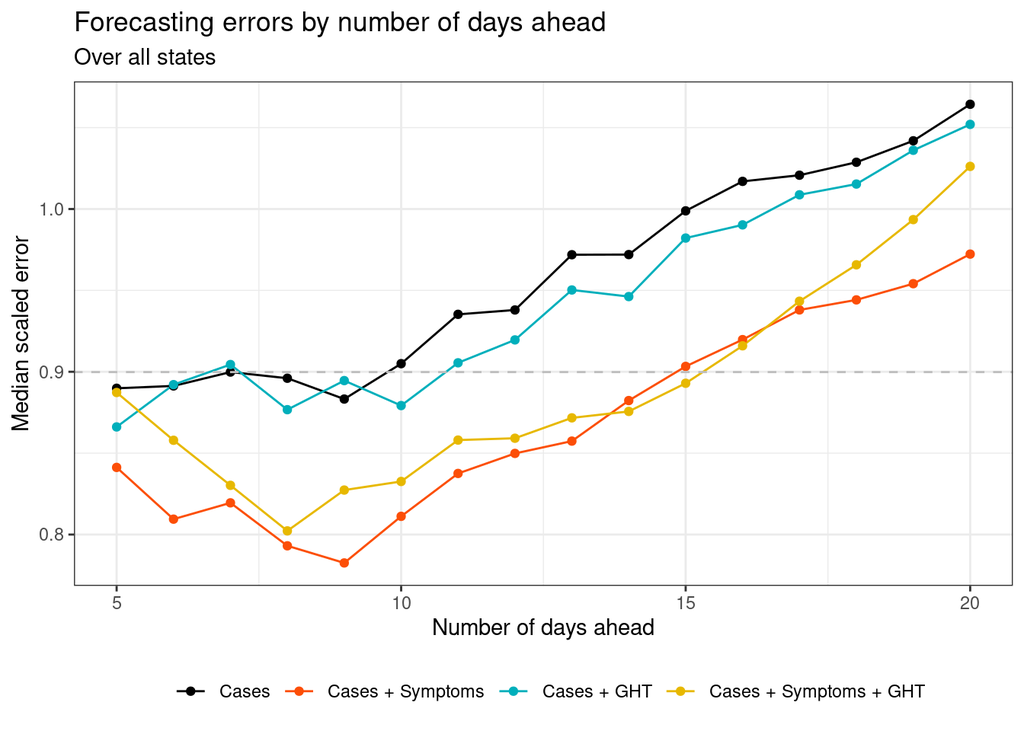

We can see that models containing GS outperform cases-only. The cases + GHT model outperforms cases-only slightly, especially at farther-ahead forecasts, but doesn’t appear to improve models that already contain the GS signal. In fact, it appears that the cases + GS + GHT model is slightly worse than the cases + GS model, especially at slightly-ahead forecasts.